# DATA 621 - Homework 1

Cheryl Bowersox, Christopher Martin, Robert Sellers, Edwige Talla Badjio

June 19, 2016

# 1 OBJECTIVE

To build an optimal multiple linear regression model for annual number of wins per team based on predictor values. The data is an annual record of baseball wins per team along with their respective explanatory statistics. The following paper outlines a procedure for the creation of three experimental regression models and explain the selection process of an optimal method.

# 2 DATA EXPLORATION

## 2.1 Summary statistics

The data has 2276 rows, with each record representing a professional baseball team from the years 1871 to 2006 inclusive. Each record has the performance of the team for the given year, with all of the statistics adjusted to match the performance of a 162 game season.

The response variable is the number of wins, or *TARGET_WINS*, which has a mean of 80.8 and standard deviation of 15.8. It follows a relatively normal, uniform distribution and we will not treat any values as outliers.

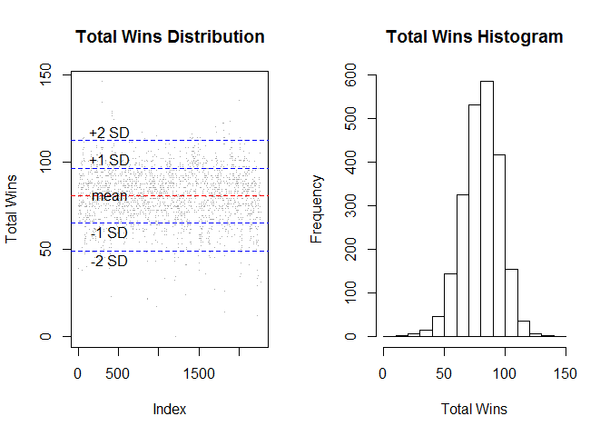

Predictive variables are much more diverse in shape and distribution (see graphical series below). The explanatory/predictor variables are the remaining variables that may have a positive or negative impact on the number of wins. ##Correlations in the data Correlations between variables were calculated, with particular interest to those > 5. One interesting result is the TARGET_WINS variable is not strongly correlated with the data, but the the pitching and batting home runs are very strongly related.

```
##                Var1             Var2     value
## 1       TARGET_WINS      TARGET_WINS 1.0000000
## 2    TEAM_BATTING_H   TEAM_BATTING_H 1.0000000
## 3   TEAM_BATTING_2B  TEAM_BATTING_2B 1.0000000
## 4   TEAM_BATTING_3B  TEAM_BATTING_3B 1.0000000
## 5   TEAM_BATTING_HR  TEAM_BATTING_HR 1.0000000
## 6   TEAM_BATTING_BB  TEAM_BATTING_BB 1.0000000
## 7   TEAM_BATTING_SO  TEAM_BATTING_SO 1.0000000
## 8   TEAM_BASERUN_SB  TEAM_BASERUN_SB 1.0000000
## 9   TEAM_BASERUN_CS  TEAM_BASERUN_CS 1.0000000
## 10 TEAM_BATTING_HBP TEAM_BATTING_HBP 1.0000000
## 11  TEAM_PITCHING_H  TEAM_PITCHING_H 1.0000000
## 12 TEAM_PITCHING_HR TEAM_PITCHING_HR 1.0000000
## 13 TEAM_PITCHING_BB TEAM_PITCHING_BB 1.0000000
## 14 TEAM_PITCHING_SO TEAM_PITCHING_SO 1.0000000
## 15  TEAM_FIELDING_E  TEAM_FIELDING_E 1.0000000
## 16 TEAM_FIELDING_DP TEAM_FIELDING_DP 1.0000000
## 17 TEAM_PITCHING_HR  TEAM_BATTING_HR 0.9693714
## 18  TEAM_BATTING_HR TEAM_PITCHING_HR 0.9693714
## 19  TEAM_FIELDING_E  TEAM_PITCHING_H 0.6677590
## 20  TEAM_PITCHING_H  TEAM_FIELDING_E 0.6677590
## 21  TEAM_BATTING_2B   TEAM_BATTING_H 0.5628497
## 22   TEAM_BATTING_H  TEAM_BATTING_2B 0.5628497
## 23  TEAM_BATTING_BB  TEAM_BATTING_HR 0.5137348
## 24  TEAM_BATTING_HR  TEAM_BATTING_BB 0.5137348
## 25  TEAM_FIELDING_E  TEAM_BATTING_3B 0.5097784
## 26  TEAM_BATTING_3B  TEAM_FIELDING_E 0.5097784
```

## 2.2 Data Visualization

Some predictor variables were chosen to evaluate the outliers and distribution of the data. The high number of ‘outliers’ may indicate a need for data transformations. In this case the base hits by batter and the field errors have a large amount of variability in the data.

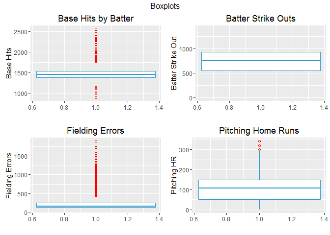

## 2.3 Missing Values

Present in the data were some concerns, namely with missing data. In its entirety there are 3478 missing fields. This amounts to 9.55% of the data available. The following graphic shows a high completeness disparity between our values. This will be discussed in greater detail and resolved in section 3 of this document.

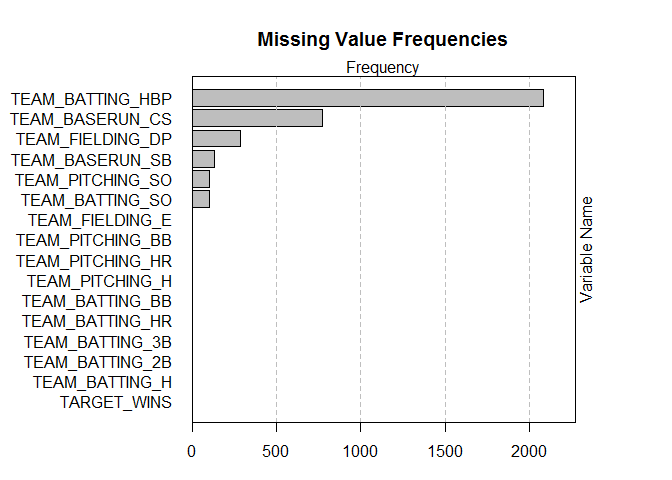

# 3 DATA PREPARATION

## 3.1 Columns added

Additionally, since (in baseball) the attacking team is the team whose turn it is at bat it might be interesting to see their success rates for those occurrences where a successful hit-at-bat occurs:

The defending team is mostly effective with the pitcher, so some added variables for pitching could be interesting:

- *TEAM_PITCHING_BADPITCH* was added for negative base pitching situations: hits off a pitch + walks allowed
- *TEAM_PITCHING_BASESGIVEN* was added for negative pitching situations: hits off a pitch + walks allowed + HRs given
- *TEAM_PITCHRATIO* was as a relationship between negative pitching outcomes (HR) and positive pitching outcomes (SO)

Other columns were added to see a form of success ratio:

- *TEAM_POSRATIO* shows the success ratio: successes in attacking (batting) vs failures in pitching
- *SBPERCENT* was added for the stolen base percentage: bases stolen vs bases caught stealing (removed from data set)

## 3.2 Columns removed

Some columns have been removed from the analysis: TEAM_BASERUN_SB, TEAM_BASERUN_CS, and TEAM_BATTING_HBP. There are a significant number of NA’s (90% of the values are missing) in the HBP column and applying a zero value to this figure is misleading. By including the values that are present in our newly created columns, we can preserve the values of gaining a base on an attacking play by being hit by a ball without the noise. A similar methodology and thought process was used for SB and CS

## 3.3 Diagnostic plots

Diagnostic plots of the variables were used to discover if any variables needed a mathematical transformation (i.e. log or square roots):

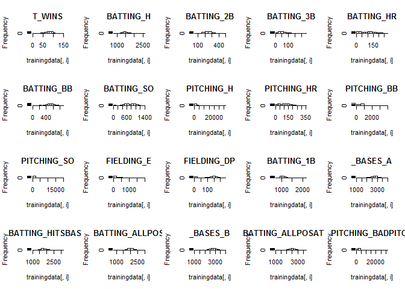

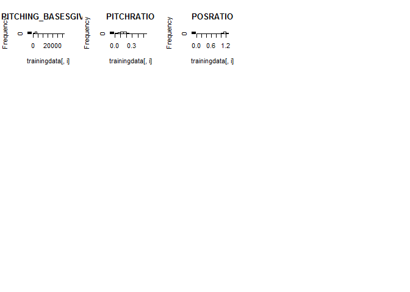

## 3.4 Mathematical transformations

Skewed variables needed to be adjusted, so the log form of the following variables was used to normalize the data:

- TEAM_BATTING_H
- TEAM_BATTING_3B
- TEAM_PITCHING_BB
- TEAM_FIELDING_E
- TEAM_BATTING_HITSBASE
- TEAM_BATTING_1B

The following variables are skewed but were not adjusted: - TEAM_PITCHING_H #PITCHING_H still has too many high values - TEAM_PITCHING_BADPITCH #high values skew - TEAM_PITCHING_BASESGIVEN #high values skew - TEAM_POSRATIO #low values skew

These fields need to be fixed: - TEAM_FIELDING_DP (0 values skew) - TOTAL_BASES (0 values are skewing–should remove 0’s) - SBPERFECT (0 values are skewing)

Remaining ‘na’ values were omited from the data set before models were created.

# 4 BUILD MODELS

## 4.1 Forward Stepwise Method

As a measure of automation accuracy and a test against more traditional models, a stepwise approach was performed using a forward AIC (Akaike information criterion) method.

Current optimal results from stepwise method with diagnostic plots

```r
#stepResults
sumary(stepResults)
```

```
##                           Estimate  Std. Error  t value  Pr(>|t|)
## (Intercept)            300.9533710  48.3434790   6.2253 5.825e-10
## TOTAL_BASES_B            0.0617399   0.0048655  12.6894 < 2.2e-16
## TEAM_PITCHING_SO        -0.0083047   0.0027682  -3.0000 0.0027323
## TEAM_FIELDING_E        -23.4927159   1.2899569 -18.2120 < 2.2e-16
## TEAM_BATTING_2B         -0.0933401   0.0100098  -9.3249 < 2.2e-16
## TEAM_BATTING_HR         -0.1768531   0.0209915  -8.4250 < 2.2e-16
## TEAM_BATTING_BB          0.0341314   0.0112872   3.0239 0.0025266
## TEAM_PITCHRATIO         41.4345456  12.2679678   3.3775 0.0007454
## TEAM_FIELDING_DP        -0.0408027   0.0095856  -4.2566 2.170e-05
## TEAM_BATTING_ALLPOS     -0.0332843   0.0069695  -4.7757 1.919e-06
## SBPERCENT                6.5380272   1.8148520   3.6025 0.0003228
## TEAM_POSRATIO          -22.1353822   5.7268715  -3.8652 0.0001145
## TEAM_PITCHING_BB       -26.8874857   7.8596741  -3.4209 0.0006364
## TEAM_PITCHING_BADPITCH   0.0118748   0.0075544   1.5719 0.1161273
## TEAM_BATTING_3B          1.8213870   1.0330535   1.7631 0.0780327
## TEAM_PITCHING_H         -0.0107521   0.0076242  -1.4103 0.1586149
##
## n = 2042, p = 16, Residual SE = 11.27498, R-Squared = 0.39
```

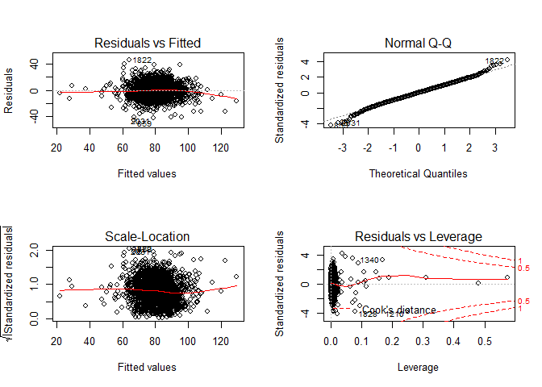

```r
par(mfrow=c(2,2))
plot(stepResults)
```

Discussion of coefficients: In the stepwise generated model many variables were selected that are linearly related to each other. The first 12 variables are statistically significant despite the multicollinearity. An argument can be made for the final 3 that they are not highly significant and could be removed. The relationships between the predictor variables result in some surprising coefficients that are difficult to directly interpret. For example The Total Bases variable has an expected positive impact on score, but the number of 2nd bases has a negative impact. Another example is the positive coefficient for the variable Pitch Ratio - this variable measures bad/good pitching outcomes, and a higher amount means a greater number of ‘bad’ outcomes (home runs allowed). The positive relationship however is probably related to the strange fact that pitching home runs allowed is highly, positively, related to the number of batting home runs - a counterintuitive relationship in the raw data.

## 4.2 Backward Elimination Model

Using backward elimination, and removing high p-value variables to get the highest adjusted $R^2$, the final regression model is:

```
##                             Estimate  Std. Error  t value  Pr(>|t|)
## (Intercept)               8.0021e+02  1.0418e+02   7.6811 2.438e-14
## TEAM_BATTING_H            8.7263e+01  1.9424e+01   4.4926 7.431e-06
## TEAM_BATTING_3B           4.6571e+00  1.3191e+00   3.5304 0.0004242
## TEAM_BATTING_HR          -2.3127e-01  3.4381e-02  -6.7268 2.250e-11
## TEAM_PITCHING_H          -1.2302e-02  7.4217e-03  -1.6576 0.0975558
## TEAM_PITCHING_BB         -2.6626e+01  5.9743e+00  -4.4568 8.773e-06
## TEAM_PITCHING_SO         -1.0034e-02  2.8204e-03  -3.5575 0.0003830
## TEAM_FIELDING_E          -2.3383e+01  1.2864e+00 -18.1764 < 2.2e-16
## TEAM_FIELDING_DP         -4.1636e-02  9.6607e-03  -4.3098 1.712e-05
## TEAM_BATTING_HITSBASE    -1.6331e+02  1.8108e+01  -9.0184 < 2.2e-16
## TOTAL_BASES_B             9.8376e-02  1.6043e-02   6.1322 1.039e-09
## TEAM_BATTING_ALLPOSATTCK -3.7203e-02  1.6391e-02  -2.2697 0.0233317
## TEAM_PITCHING_BADPITCH    1.3279e-02  7.3068e-03   1.8174 0.0693041
## TEAM_PITCHRATIO           2.8194e+01  1.2390e+01   2.2755 0.0229800
## TEAM_POSRATIO            -2.1759e+01  5.5920e+00  -3.8911 0.0001030
## SBPERCENT                 7.1149e+00  1.7895e+00   3.9759 7.257e-05
##
## n = 2042, p = 16, Residual SE = 11.26632, R-Squared = 0.39
```

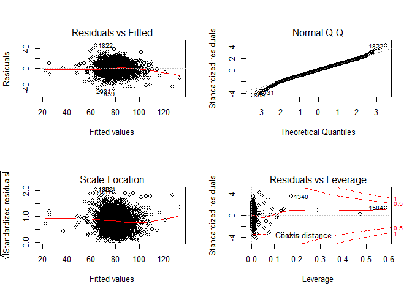

## 4.3 Simple Model

The ‘simple’ model was designed to include a limited number of input variables using a more intuitive approach to the selection as a comparison to the backwards elimination or stepwise approach. This model was created by examining the correlation between variables, choosing those that have high relationships with the target variable and lower relationships with each other. There are 3 general types of variables to choose from - batting, pitching and fielding. A single variable was chosen from each category to represent these factors.

Variables chosen: TOTAL_BASES - a linear combination of the batting variables, weighted by base number lending greater significance to higher bases. TEAM_FIELDING_E - the log of the # of fielding errors. TEAM_PITCHRATIO - This is the ratio of the number of home runs allowed versus the number of strikeouts allowed

Model Output

```
##                   Estimate Std. Error t value  Pr(>|t|)
## (Intercept)     26.3600281  4.2072616  6.2654 4.525e-10
## TOTAL_BASES_B    0.0248483  0.0012942 19.2004 < 2.2e-16
## TEAM_FIELDING_E -2.8387979  0.5977432 -4.7492 2.185e-06
## TEAM_PITCHRATIO -2.1453440  6.4311239 -0.3336    0.7387
##
## n = 2042, p = 4, Residual SE = 12.48170, R-Squared = 0.25
```

Model was re-evaluated excluding the PitchRatio variable, which slightly alters the coefficients.

Revised Model Output

```
##                    Estimate  Std. Error t value  Pr(>|t|)
## (Intercept)     26.41700087  4.20287748  6.2855 3.986e-10
## TOTAL_BASES_B    0.02457139  0.00099255 24.7558 < 2.2e-16
## TEAM_FIELDING_E -2.75847597  0.54698313 -5.0431 4.986e-07
##
## n = 2042, p = 3, Residual SE = 12.47898, R-Squared = 0.25
```

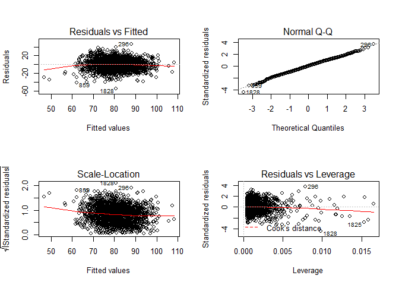

Equation with original variables:

# 5 SELECT MODELS

## 5.1 Model selection with the adjusted R squared

Assuming the model with the highest adjusted R squared is the “best” model.

## 5.2 Model selection with Aikake Information Criterion (AIC)

The idea here is that the model with the smallest AIC value is the “best”. We will be interested in the difference of AIC between fitted models.

## 5.3 Model selection with Bayesian Information Criterion (BIC)

BIC and AIC work the same. The model with the smallest BIC is the “best” in the set of models fitted.

## 5.4 Predicting TARGET_WINS using the evaluation data

### 5.4.1 Data preparation

Evaluation data was treated to the same variable transformations and handeling of ‘na’ values as the original training data set.

```r
evalData<-evaluationData
#applying same logic used for training data to deal w/ na's
evalData$TEAM_BATTING_HBP[is.na(evalData$TEAM_BATTING_HBP)] <- 0
evalData$TEAM_FIELDING_DP[is.na(evalData$TEAM_FIELDING_DP)] <- 0

evalData$TEAM_BATTING_1B<-evalData$TEAM_BATTING_H- evalData$TEAM_BATTING_2B- evalData$TEAM_BATTING_3B- evalData$TEAM_BATTING_HR

temp1B<-evalData$TEAM_BATTING_1B;temp1B[is.na(temp1B)]<-0
temp2B<-evalData$TEAM_BATTING_2B*2;temp2B[is.na(temp2B)]<-0
temp3B<-evalData$TEAM_BATTING_3B*3;temp3B[is.na(temp3B)]<-0
tempHR<-evalData$TEAM_BATTING_HR*4;tempHR[is.na(tempHR)]<-0
tempSB<-as.numeric(evalData$TEAM_BASERUN_SB);tempSB[is.na(tempSB)]<-0
tempCS<-evalData$TEAM_BASERUN_CS*-1;tempCS[is.na(tempCS)]<-0
tempBB<-as.numeric(evalData$TEAM_BATTING_BB);tempBB[is.na(tempBB)]<-0
tempHBP<-as.numeric(evalData$TEAM_BATTING_HBP);tempHBP[is.na(tempHBP)]<-0
evalData$TOTAL_BASES_A<-temp1B+temp2B+temp3B+tempHR+tempSB+tempCS+tempBB+tempHBP

evalData$TOTAL_BASES_B<-(evalData$TEAM_BATTING_2B*2)+(evalData$TEAM_BATTING_3B*3)+(evalData$TEAM_BATTING_HR*4)+ evalData$TEAM_BASERUN_SB+evalData$TEAM_BATTING_BB+evalData$TEAM_BATTING_1B

evalData$TEAM_BATTING_HITSBASE <- evalData$TEAM_BATTING_H + evalData$TEAM_BATTING_2B + evalData$TEAM_BATTING_3B


evalData$TEAM_BATTING_ALLPOS <- evalData$TEAM_BATTING_H + evalData$TEAM_BATTING_BB + evalData$TEAM_BATTING_HBP


evalData$TEAM_BATTING_ALLPOSATTCK <- evalData$TEAM_BATTING_H + evalData$TEAM_BATTING_2B + evalData$TEAM_BATTING_3B + evalData$TEAM_BATTING_HR + evalData$TEAM_BATTING_BB + evalData$TEAM_BATTING_HBP + evalData$TEAM_BASERUN_SB

evalData$TEAM_PITCHING_BADPITCH <- evalData$TEAM_PITCHING_H + evalData$TEAM_PITCHING_BB


evalData$TEAM_PITCHING_BASESGIVEN <- evalData$TEAM_PITCHING_H + evalData$TEAM_PITCHING_BB + evalData$TEAM_PITCHING_HR

evalData$TEAM_PITCHRATIO <- evalData$TEAM_PITCHING_HR / evalData$TEAM_PITCHING_SO

evalData$TEAM_POSRATIO <- evalData$TEAM_BATTING_ALLPOSATTCK / evalData$TEAM_PITCHING_BASESGIVEN

evalData$SBPERCENT <- evalData$TEAM_BASERUN_SB / (evalData$TEAM_BASERUN_SB + evalData$TEAM_BASERUN_CS)

evalData$TEAM_BATTING_H <- log(evalData$TEAM_BATTING_H)
evalData$TEAM_BATTING_3B <- log(evalData$TEAM_BATTING_3B)
evalData$TEAM_PITCHING_BB <- log(evalData$TEAM_PITCHING_BB)
evalData$TEAM_FIELDING_E <- log(evalData$TEAM_FIELDING_E)
evalData$TEAM_BATTING_HITSBASE <- log(evalData$TEAM_BATTING_HITSBASE)
evalData$TEAM_BATTING_1B <- log(evalData$TEAM_BATTING_1B)

evalData<-evalData%>%select(-TEAM_BATTING_HBP)
evalData$TEAM_BASERUN_SB <- NULL
evalData$TEAM_BASERUN_CS <- NULL


# variables actually need for our model, creating subset so we don't worry about the na's in other fields

evalDatasub <- evalData%>%select(TOTAL_BASES_B, TEAM_PITCHING_SO, TEAM_FIELDING_E, TEAM_BATTING_2B, TEAM_BATTING_HR,TEAM_BATTING_BB, TEAM_PITCHRATIO,TEAM_FIELDING_DP,TEAM_BATTING_ALLPOS,TEAM_POSRATIO,TEAM_PITCHING_BB,TEAM_PITCHING_BADPITCH,TEAM_PITCHING_H,TEAM_BATTING_3B,SBPERCENT)


# 259 obs,31 are NA

evalDatasub<-na.omit(evalDatasub)
```

### 5.4.2 Prediction

```r
evalDatasub$TARGET_WINS<-predict(best_model, newdata=evalDatasub, type='response')
```

We were able to use our selected model to predict Target Wins for the evaluation data for 228 complete observations out of the 259 total available. We found the mean of the predicted values was81.2145352 with a standard deviation of 8.0708116. This can be compared to the mean and standard deviation of the training data set used to create the model of 80.7908612 and 15.7521525. Comparing density of actual wins vs. predict wins

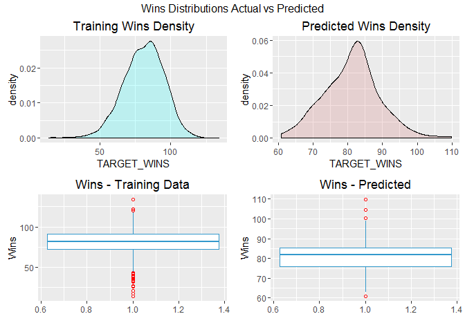

***

# 6 APPENDIX